# PlotMicrobiome analysis with AI report

### Top 10 taxa ordered by FDR

|  | stats | P | FDR | Enriched | Fold_change | significance |
| --- | --- | --- | --- | --- | --- | --- |
| d__Bacteria–p__Actinobacteriota–c__Coriobacteriia–o__Coriobacteriales–f__Coriobacteriaceae | 334 | 6.01798149679332e-05 | 0.00670001939976323 | rural | 0.0651060214341998 | significant |
| d__Bacteria–p__Actinobacteriota–c__Coriobacteriia–o__Coriobacteriales–f__Coriobacteriaceae–g__Collinsella | 334 | 6.01798149679332e-05 | 0.00670001939976323 | rural | 0.0651060214341998 | significant |
| d__Bacteria–p__Actinobacteriota–c__Coriobacteriia–o__Coriobacteriales–f__Coriobacteriaceae–g**Collinsella–** | 334 | 6.01798149679332e-05 | 0.00670001939976323 | rural | 0.0651060214341998 | significant |
| d__Bacteria–p__Bacteroidota–c__Bacteroidia–o__Bacteroidales–f__Bacteroidaceae–g**Bacteroides–** | 74 | 0.000419438171529868 | 0.035023087322744 | urban | 2.34648703097836 | significant |
| d__Bacteria–p__Fusobacteriota–c__Fusobacteriia–o__Fusobacteriales–f__Fusobacteriaceae–g**Fusobacterium–** | 86.5 | 0.000557237990591269 | 0.0372234977714968 | urban | 305.208724021588 | significant |
| d__Bacteria–p__Proteobacteria–c__Gammaproteobacteria–o__Burkholderiales–f__Sutterellaceae–g__Sutterella | 321 | 0.000952610415782356 | 0.0521061986516346 | rural | 0.190932993803365 | significant |
| d__Bacteria–p__Firmicutes–c__Clostridia–o__Lachnospirales–f__Lachnospiraceae–g__Lachnospiraceae_FCS020_group | 316 | 0.00124236911005547 | 0.0521061986516346 | rural | 0.197703699167705 | significant |
| d__Bacteria–p__Bacteroidota–c__Bacteroidia–o__Bacteroidales–f__Bacteroidaceae | 86 | 0.00159315947873282 | 0.0521061986516346 | urban | 1.87904789837732 | significant |
| d__Bacteria–p__Bacteroidota–c__Bacteroidia–o__Bacteroidales–f__Bacteroidaceae–g__Bacteroides | 86 | 0.00159315947873282 | 0.0521061986516346 | urban | 1.87904789837732 | significant |
| d__Bacteria–p__Firmicutes–c__Clostridia–o__Oscillospirales–f__Oscillospiraceae–g**uncultured–** | 99 | 0.00176955043636269 | 0.0521061986516346 | urban | 16.9346541149857 | significant |

### Boxplot of most signficant taxa (ordered by FDR)

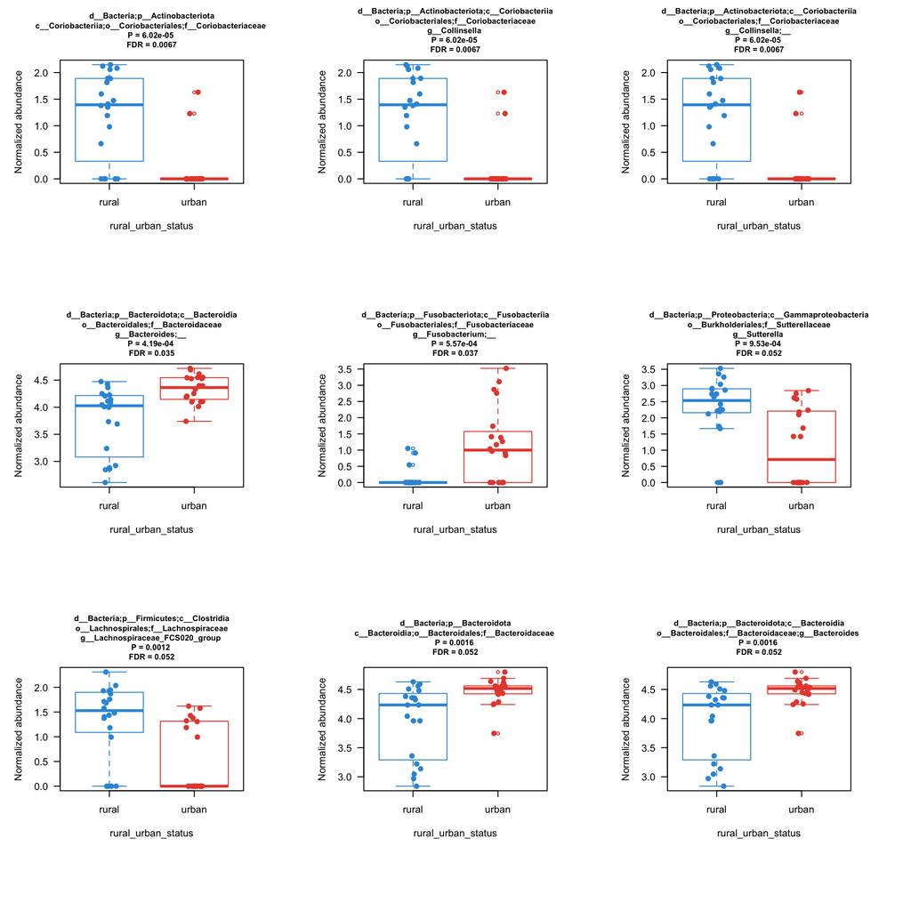